# Chapter 4: Clustering and classification

## LDA on clusters

I perform k-means on the standardized dataset with an increased number of cluster equal to 7.

```r
# scale variables and set as data frame class
boston_scaled <- scale(boston_scaled)
boston_scaled <- as.data.frame(boston_scaled)

# k-means on 7 clusters
km <-kmeans(boston_scaled, centers = 7)
cluster <- km$cluster
boston_scaled <- data.frame(boston_scaled,cluster)

# divide train and test datasets
ind <- sample(n,  size = n * 0.8)
train <- boston_scaled[ind,]
test <- boston_scaled[-ind,]
```

Perform LDA using the clusters as target classes. Include all the variables in the Boston data in the LDA model. Visualize the results with a biplot (include arrows representing the relationships of the original variables to the LDA solution).

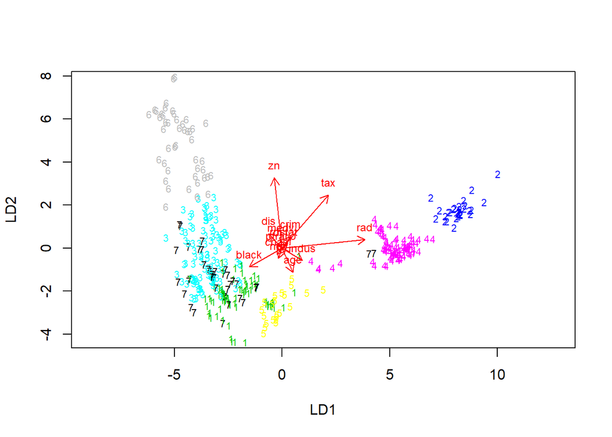

The most influencial separators seem to be ‘tax’, ‘rad, ’zn’.

I now study how the model predict the classes, on the test subset formed by 102 observations: notice that good predictive power of the model.

```
##        predicted
## correct  1  2  3  4  5  6  7
##       1 28  0  4  0  0  0  0
##       2  0  7  0  2  0  0  0
##       3  1  0 20  0  0  0  0
##       4  0  0  0 14  0  0  0
##       5  0  0  1  0  3  0  0
##       6  0  0  0  0  0 11  0
##       7  0  0  1  1  0  0  9
```